# Project: Investigate a Dataset - [TMDB-Movies]

- Introduction
- Data Wrangling
- Exploratory Data Analysis
- Conclusions

## Introduction

### Dataset Description

> The data set I have chosen to analyze is the tmdb movies data set which contains information about various movies stored in the movie database (TMDb). This data set contains data on over 10,000 movies including the user ratings, year and date of release, name of director, cast, runtime, budget and revenue generated from the movies.

### Question(s) for Analysis

> In this analysis, I will be focusing on the features that impact profitability and revenue of movie productions as well as their profit margins in general. My analysis will try to answer the following questions:
- Which movies were the most and least profitable movies
- Which are the top 10 production companies who generated the most profit
- Who are the top 10 movie Directors who generated the most profit and revenue
- Top 10 Movie Genres that generated the most profit and revenue
- Does higher budgets result in higher revenue?
- Does higher or increased revenue guarantee profits?
- Will higher budgets result in profit generation?
- Are movies with higher popularity ratings guaranteed to make profits?
- Does the popularity rating of a movie impact the revenue generation?
- Do all movie productions generate revenue?
- Does revenue generation from movie production guarantee profits?

```python
# Import relevant packages required for the analysis.

import pandas as pd
import numpy as np
import matplotlib.pyplot as plt
%matplotlib inline
import seaborn as sns
```

## Data Wrangling

> **Tip**: In this section of the report, I will load the dataset, check for cleanliness, and then trim and clean the dataset by checking for null, duplicate and irrelevant values. I will also inspect the number of columns and rows, data types and general information on the dataset.

### General Properties

```python
# Load the dataset and print an overview of the dataset.
# print out a few lines. Perform operations to inspect data.
# types and look for instances of missing or possibly errant data.

movies_df = pd.read_csv('tmdb-movies.csv')
movies_df.head()
```

|  | id | imdb_id | popularity | budget | revenue | original_title | cast | homepage | director | tagline | ... | overview | runtime | genres | production_companies | release_date | vote_count | vote_average | release_year | budget_adj | revenue_adj |
| --- | --- | --- | --- | --- | --- | --- | --- | --- | --- | --- | --- | --- | --- | --- | --- | --- | --- | --- | --- | --- | --- |
| 0 | 135397 | tt0369610 | 32.985763 | 150000000 | 1513528810 | Jurassic World | Chris Pratt\|Bryce Dallas Howard\|Irrfan Khan\|Vi... | http://www.jurassicworld.com/ | Colin Trevorrow | The park is open. | ... | Twenty-two years after the events of Jurassic ... | 124 | Action\|Adventure\|Science Fiction\|Thriller | Universal Studios\|Amblin Entertainment\|Legenda... | 6/9/15 | 5562 | 6.5 | 2015 | 1.379999e+08 | 1.392446e+09 |
| 1 | 76341 | tt1392190 | 28.419936 | 150000000 | 378436354 | Mad Max: Fury Road | Tom Hardy\|Charlize Theron\|Hugh Keays-Byrne\|Nic... | http://www.madmaxmovie.com/ | George Miller | What a Lovely Day. | ... | An apocalyptic story set in the furthest reach... | 120 | Action\|Adventure\|Science Fiction\|Thriller | Village Roadshow Pictures\|Kennedy Miller Produ... | 5/13/15 | 6185 | 7.1 | 2015 | 1.379999e+08 | 3.481613e+08 |
| 2 | 262500 | tt2908446 | 13.112507 | 110000000 | 295238201 | Insurgent | Shailene Woodley\|Theo James\|Kate Winslet\|Ansel... | http://www.thedivergentseries.movie/#insurgent | Robert Schwentke | One Choice Can Destroy You | ... | Beatrice Prior must confront her inner demons ... | 119 | Adventure\|Science Fiction\|Thriller | Summit Entertainment\|Mandeville Films\|Red Wago... | 3/18/15 | 2480 | 6.3 | 2015 | 1.012000e+08 | 2.716190e+08 |
| 3 | 140607 | tt2488496 | 11.173104 | 200000000 | 2068178225 | Star Wars: The Force Awakens | Harrison Ford\|Mark Hamill\|Carrie Fisher\|Adam D... | http://www.starwars.com/films/star-wars-episod... | J.J. Abrams | Every generation has a story. | ... | Thirty years after defeating the Galactic Empi... | 136 | Action\|Adventure\|Science Fiction\|Fantasy | Lucasfilm\|Truenorth Productions\|Bad Robot | 12/15/15 | 5292 | 7.5 | 2015 | 1.839999e+08 | 1.902723e+09 |
| 4 | 168259 | tt2820852 | 9.335014 | 190000000 | 1506249360 | Furious 7 | Vin Diesel\|Paul Walker\|Jason Statham\|Michelle ... | http://www.furious7.com/ | James Wan | Vengeance Hits Home | ... | Deckard Shaw seeks revenge against Dominic Tor... | 137 | Action\|Crime\|Thriller | Universal Pictures\|Original Film\|Media Rights ... | 4/1/15 | 2947 | 7.3 | 2015 | 1.747999e+08 | 1.385749e+09 |

5 rows × 21 columns

```python
# view informtion on the dataset
movies_df.info()
```

```
<class 'pandas.core.frame.DataFrame'>
RangeIndex: 10866 entries, 0 to 10865
Data columns (total 21 columns):
 #   Column                Non-Null Count  Dtype
---  ------                --------------  -----
 0   id                    10866 non-null  int64
 1   imdb_id               10856 non-null  object
 2   popularity            10866 non-null  float64
 3   budget                10866 non-null  int64
 4   revenue               10866 non-null  int64
 5   original_title        10866 non-null  object
 6   cast                  10790 non-null  object
 7   homepage              2936 non-null   object
 8   director              10822 non-null  object
 9   tagline               8042 non-null   object
 10  keywords              9373 non-null   object
 11  overview              10862 non-null  object
 12  runtime               10866 non-null  int64
 13  genres                10843 non-null  object
 14  production_companies  9836 non-null   object
 15  release_date          10866 non-null  object
 16  vote_count            10866 non-null  int64
 17  vote_average          10866 non-null  float64
 18  release_year          10866 non-null  int64
 19  budget_adj            10866 non-null  float64
 20  revenue_adj           10866 non-null  float64
dtypes: float64(4), int64(6), object(11)
memory usage: 1.7+ MB
```

```python
# confirm the number of rows and columns
movies_df.shape
```

```
(10866, 21)
```

```python
#check the data types for the columns
movies_df.dtypes
```

```
id                        int64
imdb_id                  object
popularity              float64
budget                    int64
revenue                   int64
original_title           object
cast                     object
homepage                 object
director                 object
tagline                  object
keywords                 object
overview                 object
runtime                   int64
genres                   object
production_companies     object
release_date             object
vote_count                int64
vote_average            float64
release_year              int64
budget_adj              float64
revenue_adj             float64
dtype: object
```

```python
#check for null and missing values
movies_df.isnull().sum()
```

```
id                         0
imdb_id                   10
popularity                 0
budget                     0
revenue                    0
original_title             0
cast                      76
homepage                7930
director                  44
tagline                 2824
keywords                1493
overview                   4
runtime                    0
genres                    23
production_companies    1030
release_date               0
vote_count                 0
vote_average               0
release_year               0
budget_adj                 0
revenue_adj                0
dtype: int64
```

```python
#View more statistical information on the dataset.
movies_df.describe()
```

|  | id | popularity | budget | revenue | runtime | vote_count | vote_average | release_year | budget_adj | revenue_adj |
| --- | --- | --- | --- | --- | --- | --- | --- | --- | --- | --- |
| count | 10866.000000 | 10866.000000 | 1.086600e+04 | 1.086600e+04 | 10866.000000 | 10866.000000 | 10866.000000 | 10866.000000 | 1.086600e+04 | 1.086600e+04 |
| mean | 66064.177434 | 0.646441 | 1.462570e+07 | 3.982332e+07 | 102.070863 | 217.389748 | 5.974922 | 2001.322658 | 1.755104e+07 | 5.136436e+07 |
| std | 92130.136561 | 1.000185 | 3.091321e+07 | 1.170035e+08 | 31.381405 | 575.619058 | 0.935142 | 12.812941 | 3.430616e+07 | 1.446325e+08 |
| min | 5.000000 | 0.000065 | 0.000000e+00 | 0.000000e+00 | 0.000000 | 10.000000 | 1.500000 | 1960.000000 | 0.000000e+00 | 0.000000e+00 |
| 25% | 10596.250000 | 0.207583 | 0.000000e+00 | 0.000000e+00 | 90.000000 | 17.000000 | 5.400000 | 1995.000000 | 0.000000e+00 | 0.000000e+00 |
| 50% | 20669.000000 | 0.383856 | 0.000000e+00 | 0.000000e+00 | 99.000000 | 38.000000 | 6.000000 | 2006.000000 | 0.000000e+00 | 0.000000e+00 |
| 75% | 75610.000000 | 0.713817 | 1.500000e+07 | 2.400000e+07 | 111.000000 | 145.750000 | 6.600000 | 2011.000000 | 2.085325e+07 | 3.369710e+07 |
| max | 417859.000000 | 32.985763 | 4.250000e+08 | 2.781506e+09 | 900.000000 | 9767.000000 | 9.200000 | 2015.000000 | 4.250000e+08 | 2.827124e+09 |

```python
#check for duplicates
movies_df.duplicated().sum()
```

```
1
```

```python
#find the duplicated record
movies_df[movies_df.duplicated()]
```

|  | id | imdb_id | popularity | budget | revenue | original_title | cast | homepage | director | tagline | ... | overview | runtime | genres | production_companies | release_date | vote_count | vote_average | release_year | budget_adj | revenue_adj |
| --- | --- | --- | --- | --- | --- | --- | --- | --- | --- | --- | --- | --- | --- | --- | --- | --- | --- | --- | --- | --- | --- |
| 2090 | 42194 | tt0411951 | 0.59643 | 30000000 | 967000 | TEKKEN | Jon Foo\|Kelly Overton\|Cary-Hiroyuki Tagawa\|Ian... | NaN | Dwight H. Little | Survival is no game | ... | In the year of 2039, after World Wars destroy ... | 92 | Crime\|Drama\|Action\|Thriller\|Science Fiction | Namco\|Light Song Films | 3/20/10 | 110 | 5.0 | 2010 | 30000000.0 | 967000.0 |

1 rows × 21 columns

### Data Cleaning

> From the dataset, I can see that there is one duplicate record and several features with missing and null values. There are also columns that will not be relevant to the analysis I am doing hence these columns will be dropped. The release date also has a data type of String which will be formatted to a date time format.

```python
# Remove duplicate values from the dataset
movies_df.drop_duplicates(inplace=True);
```

```python
#confirm that duplicates have been removed
movies_df.duplicated().sum()
```

```
0
```

```python
#drop columns that will not be required for the analysis
cols = ['imdb_id','homepage','tagline','overview','budget_adj','revenue_adj']
movies_df.drop(cols, axis=1, inplace=True)
```

```python
#confirm that irrelevant columns have been dropped.
movies_df.shape
```

```
(10865, 15)
```

```python
#remove rows with missing or null values
movies_df.dropna(inplace=True)
```

```python
#confirm that missing and null values have been dropped
movies_df.shape
```

```
(8666, 15)
```

```python
movies_df.info()
```

```
<class 'pandas.core.frame.DataFrame'>
Int64Index: 8666 entries, 0 to 10865
Data columns (total 15 columns):
 #   Column                Non-Null Count  Dtype
---  ------                --------------  -----
 0   id                    8666 non-null   int64
 1   popularity            8666 non-null   float64
 2   budget                8666 non-null   int64
 3   revenue               8666 non-null   int64
 4   original_title        8666 non-null   object
 5   cast                  8666 non-null   object
 6   director              8666 non-null   object
 7   keywords              8666 non-null   object
 8   runtime               8666 non-null   int64
 9   genres                8666 non-null   object
 10  production_companies  8666 non-null   object
 11  release_date          8666 non-null   object
 12  vote_count            8666 non-null   int64
 13  vote_average          8666 non-null   float64
 14  release_year          8666 non-null   int64
dtypes: float64(2), int64(6), object(7)
memory usage: 1.1+ MB
```

```python
#Convert the data type for the release date column to a date time format
movies_df['release_date'] = pd.to_datetime(movies_df['release_date'])
movies_df['release_date'].head()
```

```
0   2015-06-09
1   2015-05-13
2   2015-03-18
3   2015-12-15
4   2015-04-01
Name: release_date, dtype: datetime64[ns]
```

```python
#Add the column for profit generated for the individual movies
movies_df['profit'] = movies_df['revenue']-movies_df['budget']
movies_df.head()
```

|  | id | popularity | budget | revenue | original_title | cast | director | keywords | runtime | genres | production_companies | release_date | vote_count | vote_average | release_year | profit |
| --- | --- | --- | --- | --- | --- | --- | --- | --- | --- | --- | --- | --- | --- | --- | --- | --- |
| 0 | 135397 | 32.985763 | 150000000 | 1513528810 | Jurassic World | Chris Pratt\|Bryce Dallas Howard\|Irrfan Khan\|Vi... | Colin Trevorrow | monster\|dna\|tyrannosaurus rex\|velociraptor\|island | 124 | Action\|Adventure\|Science Fiction\|Thriller | Universal Studios\|Amblin Entertainment\|Legenda... | 2015-06-09 | 5562 | 6.5 | 2015 | 1363528810 |
| 1 | 76341 | 28.419936 | 150000000 | 378436354 | Mad Max: Fury Road | Tom Hardy\|Charlize Theron\|Hugh Keays-Byrne\|Nic... | George Miller | future\|chase\|post-apocalyptic\|dystopia\|australia | 120 | Action\|Adventure\|Science Fiction\|Thriller | Village Roadshow Pictures\|Kennedy Miller Produ... | 2015-05-13 | 6185 | 7.1 | 2015 | 228436354 |
| 2 | 262500 | 13.112507 | 110000000 | 295238201 | Insurgent | Shailene Woodley\|Theo James\|Kate Winslet\|Ansel... | Robert Schwentke | based on novel\|revolution\|dystopia\|sequel\|dyst... | 119 | Adventure\|Science Fiction\|Thriller | Summit Entertainment\|Mandeville Films\|Red Wago... | 2015-03-18 | 2480 | 6.3 | 2015 | 185238201 |
| 3 | 140607 | 11.173104 | 200000000 | 2068178225 | Star Wars: The Force Awakens | Harrison Ford\|Mark Hamill\|Carrie Fisher\|Adam D... | J.J. Abrams | android\|spaceship\|jedi\|space opera\|3d | 136 | Action\|Adventure\|Science Fiction\|Fantasy | Lucasfilm\|Truenorth Productions\|Bad Robot | 2015-12-15 | 5292 | 7.5 | 2015 | 1868178225 |
| 4 | 168259 | 9.335014 | 190000000 | 1506249360 | Furious 7 | Vin Diesel\|Paul Walker\|Jason Statham\|Michelle ... | James Wan | car race\|speed\|revenge\|suspense\|car | 137 | Action\|Crime\|Thriller | Universal Pictures\|Original Film\|Media Rights ... | 2015-04-01 | 2947 | 7.3 | 2015 | 1316249360 |

```python
#review the statistics of the final table after cleaning
movies_df.describe()
```

|  | id | popularity | budget | revenue | runtime | vote_count | vote_average | release_year | profit |
| --- | --- | --- | --- | --- | --- | --- | --- | --- | --- |
| count | 8666.000000 | 8666.000000 | 8.666000e+03 | 8.666000e+03 | 8666.000000 | 8666.000000 | 8666.000000 | 8666.000000 | 8.666000e+03 |
| mean | 57003.179206 | 0.741937 | 1.770937e+07 | 4.924863e+07 | 103.815140 | 264.204823 | 6.003612 | 2000.129818 | 3.153926e+07 |
| std | 86242.565745 | 1.087657 | 3.357362e+07 | 1.289529e+08 | 26.207186 | 635.195808 | 0.893539 | 13.221278 | 1.069616e+08 |
| min | 5.000000 | 0.000188 | 0.000000e+00 | 0.000000e+00 | 0.000000 | 10.000000 | 1.500000 | 1960.000000 | -4.139124e+08 |
| 25% | 9816.750000 | 0.249990 | 0.000000e+00 | 0.000000e+00 | 91.000000 | 20.000000 | 5.500000 | 1993.000000 | 0.000000e+00 |
| 50% | 16216.500000 | 0.449377 | 1.500000e+06 | 1.793820e+05 | 100.000000 | 54.000000 | 6.100000 | 2004.000000 | 0.000000e+00 |
| 75% | 54003.000000 | 0.842984 | 2.100000e+07 | 3.890269e+07 | 113.000000 | 200.000000 | 6.600000 | 2011.000000 | 1.966175e+07 |
| max | 417859.000000 | 32.985763 | 4.250000e+08 | 2.781506e+09 | 705.000000 | 9767.000000 | 8.700000 | 2015.000000 | 2.544506e+09 |

## Exploratory Data Analysis

> **Tip**: Now that you've trimmed and cleaned your data, you're ready to move on to exploration. Compute statistics and create visualizations with the goal of addressing the research questions that you posed in the Introduction section. It is recommended that you be systematic with your approach. Look at one variable at a time, and then follow it up by looking at relationships between variables.

### Data Exploration

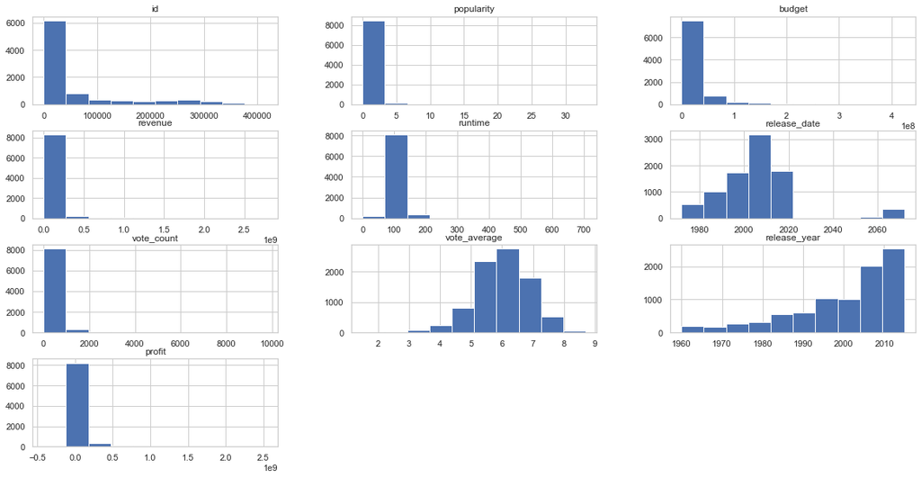

```python
# Use histograms to explore the dataset to see the distribution of the data in various coulmns
movies_df.hist(figsize=(20,10));
```

### Research Question 1 (Which movies were the most and least profitable movies)

```python
#Review the statistical structure of the profit column
movies_df['profit'].describe()
```

```
count    8.666000e+03
mean     3.153926e+07
std      1.069616e+08
min     -4.139124e+08
25%      0.000000e+00
50%      0.000000e+00
75%      1.966175e+07
max      2.544506e+09
Name: profit, dtype: float64
```

```python
#Create a new function to automate the generation of the movies with the highest and lowest profit.

def profit_maxmin(p):
    #use the 'idmax' and 'idmin' functions to find the index of highest and lowest profit movies.
    max_index = movies_df[p].idxmax()
    low_index = movies_df[p].idxmin()
    max_profit = pd.DataFrame(movies_df.loc[max_index,:])
    low_profit = pd.DataFrame(movies_df.loc[low_index,:])
    mov_profit = pd.concat([max_profit,low_profit],axis = 1)

    #print the details of the movies having the highest and lowest profits
    print("The movie with the highest profit is " + " = ", movies_df['original_title'][max_index], "with a profit of $",  movies_df['profit'].max())
    print("The movie with the least profit is " + "  = ", movies_df['original_title'][low_index], "with a profit of $",  movies_df['profit'].min())

    return mov_profit
```

```python
#invoke the profit_maxmin function to know the movies with the most and least profits
profit_maxmin('profit')
```

```
The movie with the highest profit is  =  Avatar with a profit of $ 2544505847
The movie with the least profit is   =  The Warrior's Way with a profit of $ -413912431
```

|  | 1386 | 2244 |
| --- | --- | --- |
| id | 19995 | 46528 |
| popularity | 9.432768 | 0.25054 |
| budget | 237000000 | 425000000 |
| revenue | 2781505847 | 11087569 |
| original_title | Avatar | The Warrior's Way |
| cast | Sam Worthington\|Zoe Saldana\|Sigourney Weaver\|S... | Kate Bosworth\|Jang Dong-gun\|Geoffrey Rush\|Dann... |
| director | James Cameron | Sngmoo Lee |
| keywords | culture clash\|future\|space war\|space colony\|so... | assassin\|small town\|revenge\|deception\|super speed |
| runtime | 162 | 100 |
| genres | Action\|Adventure\|Fantasy\|Science Fiction | Adventure\|Fantasy\|Action\|Western\|Thriller |
| production_companies | Ingenious Film Partners\|Twentieth Century Fox ... | Boram Entertainment Inc. |
| release_date | 2009-12-10 00:00:00 | 2010-12-02 00:00:00 |
| vote_count | 8458 | 74 |
| vote_average | 7.1 | 6.4 |
| release_year | 2009 | 2010 |
| profit | 2544505847 | -413912431 |

#### The analysis shows that Avatar is the highest grossing moving in term of profit while The warriors way made the most losses.

### Research Question 2 (Which are the top 10 production companies who generated the most profit)

```python
# Aggregate the profit amounts generated by each production company to know the top 10 by profit.

comp_profit = movies_df.groupby('production_companies').sum('profit').sort_values(by='profit', ascending=False).head(10)
comp_profit
```

| production_companies | id | popularity | budget | revenue | runtime | vote_count | vote_average | release_year | profit |
| --- | --- | --- | --- | --- | --- | --- | --- | --- | --- |
| Paramount Pictures | 2406535 | 94.155188 | 2055504915 | 7946003257 | 15831 | 28563 | 933.7 | 300359 | 5890498342 |
| Walt Disney Pictures\|Pixar Animation Studios | 747149 | 45.073337 | 1857000000 | 7648558520 | 1327 | 36758 | 120.1 | 34110 | 5791558520 |
| Marvel Studios | 1877737 | 62.011434 | 1371000000 | 6047908966 | 1667 | 43295 | 146.9 | 44241 | 4676908966 |
| DreamWorks Animation | 1205643 | 31.563245 | 2047000000 | 6676741096 | 1565 | 16447 | 152.1 | 48206 | 4629741096 |
| Blue Sky Studios\|Twentieth Century Fox Animation | 412324 | 16.298030 | 633000000 | 3938820202 | 664 | 8991 | 44.3 | 14070 | 3305820202 |
| Columbia Pictures | 1213351 | 45.488173 | 1679620000 | 4925479137 | 7955 | 20163 | 432.5 | 141463 | 3245859137 |
| Universal Pictures\|Illumination Entertainment | 449562 | 17.614339 | 352000000 | 3203800871 | 465 | 12152 | 32.3 | 10061 | 2851800871 |
| Ingenious Film Partners\|Twentieth Century Fox Film Corporation\|Dune Entertainment\|Lightstorm Entertainment | 19995 | 9.432768 | 237000000 | 2781505847 | 162 | 8458 | 7.1 | 2009 | 2544505847 |
| Walt Disney Pictures\|Walt Disney Animation Studios | 1020212 | 28.526145 | 1061500000 | 3498726837 | 767 | 12987 | 75.0 | 22110 | 2437226837 |
| Universal Pictures | 2294053 | 61.951855 | 1317633695 | 3746895082 | 12667 | 14104 | 720.0 | 238699 | 2429261387 |

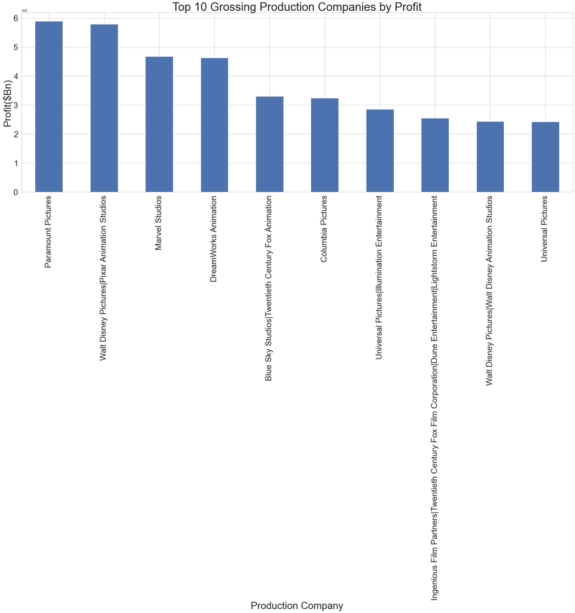

```python
#Bar chart showing the visual representation of the top 10 production company's by profit generated.
comp_profit.profit.plot.bar(figsize=(30, 10), fontsize=25);

plt.title('Top 10 Grossing Production Companies by Profit',fontsize = 35)
plt.xlabel('Production Company',fontsize = 30)
plt.ylabel('Profit($Bn)',fontsize = 30);
```

#### The plot shows that Paramount pictures has generated the most profit among all the production companies with about 5.8bn.

### Research Question 3 (Who are the top 10 movie Directors who generated the most profit and revenue)

```python
#Analyze the top 10 Directors who generated the most profit
dir_profit = movies_df.groupby('director').sum('profit').sort_values(by='profit', ascending=False).head(10)
dir_profit
```

| director | id | popularity | budget | revenue | runtime | vote_count | vote_average | release_year | profit |
| --- | --- | --- | --- | --- | --- | --- | --- | --- | --- |
| Steven Spielberg | 503569 | 54.378995 | 1589950000 | 9018563772 | 3900 | 36735 | 197.9 | 57818 | 7428613772 |
| Peter Jackson | 268469 | 49.067904 | 1326775710 | 6523244659 | 1853 | 31796 | 91.0 | 26017 | 5196468949 |
| James Cameron | 86462 | 28.477482 | 759900000 | 5841894863 | 1110 | 21756 | 56.8 | 15953 | 5081994863 |
| Michael Bay | 305181 | 22.254874 | 1360000000 | 4917208171 | 1614 | 17477 | 69.6 | 22052 | 3557208171 |
| David Yates | 26331 | 20.506537 | 775000000 | 4154295625 | 567 | 13819 | 29.6 | 8037 | 3379295625 |
| Chris Columbus | 355516 | 31.514525 | 627000000 | 3851491668 | 1685 | 15169 | 89.6 | 27987 | 3224491668 |
| Christopher Nolan | 247175 | 61.786664 | 1005000000 | 4167548502 | 1204 | 41712 | 68.2 | 18055 | 3162548502 |
| George Lucas | 7167 | 23.461834 | 360554000 | 3316550893 | 735 | 12699 | 40.2 | 11927 | 2955996893 |
| J.J. Abrams | 246862 | 24.004784 | 740000000 | 3579169916 | 633 | 14962 | 35.1 | 10054 | 2839169916 |
| Robert Zemeckis | 497840 | 33.155528 | 925700000 | 3714226518 | 1880 | 21298 | 107.9 | 31924 | 2788526518 |

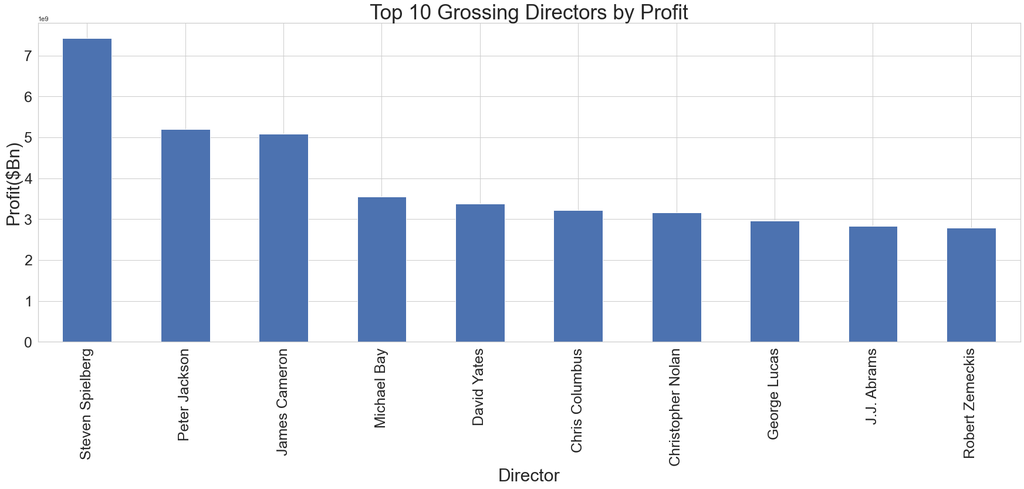

```python
#Visualize the top 10 Directors who generated the most profit using bar charts
dir_profit.profit.plot.bar(figsize=(30, 10), fontsize=25);

plt.title('Top 10 Grossing Directors by Profit',fontsize = 35)
plt.xlabel('Director',fontsize = 30)
plt.ylabel('Profit($Bn)',fontsize = 30);
```

#### The plot shows that Steven Spielberg is the highest grossing movie Director based on profit generated with about 7.5bn.

```python
#Analyze the top 10 Directors who generated the most revenue
dir_revenue = movies_df.groupby('director').sum().sort_values(by='revenue', ascending=False).head(10)
dir_revenue
```

| director | id | popularity | budget | revenue | runtime | vote_count | vote_average | release_year | profit |
| --- | --- | --- | --- | --- | --- | --- | --- | --- | --- |
| Steven Spielberg | 503569 | 54.378995 | 1589950000 | 9018563772 | 3900 | 36735 | 197.9 | 57818 | 7428613772 |
| Peter Jackson | 268469 | 49.067904 | 1326775710 | 6523244659 | 1853 | 31796 | 91.0 | 26017 | 5196468949 |
| James Cameron | 86462 | 28.477482 | 759900000 | 5841894863 | 1110 | 21756 | 56.8 | 15953 | 5081994863 |
| Michael Bay | 305181 | 22.254874 | 1360000000 | 4917208171 | 1614 | 17477 | 69.6 | 22052 | 3557208171 |
| Christopher Nolan | 247175 | 61.786664 | 1005000000 | 4167548502 | 1204 | 41712 | 68.2 | 18055 | 3162548502 |
| David Yates | 26331 | 20.506537 | 775000000 | 4154295625 | 567 | 13819 | 29.6 | 8037 | 3379295625 |
| Chris Columbus | 355516 | 31.514525 | 627000000 | 3851491668 | 1685 | 15169 | 89.6 | 27987 | 3224491668 |
| Robert Zemeckis | 497840 | 33.155528 | 925700000 | 3714226518 | 1880 | 21298 | 107.9 | 31924 | 2788526518 |
| Tim Burton | 318886 | 34.615648 | 1113060000 | 3665414624 | 1800 | 17309 | 119.9 | 35963 | 2552354624 |
| Ridley Scott | 765883 | 46.213770 | 1482900000 | 3649996480 | 2985 | 24801 | 149.0 | 45970 | 2167096480 |

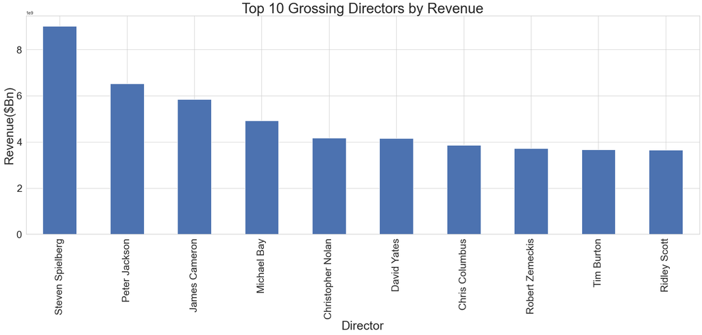

```python
#Visualize the top 10 Directors who generated the most profit using bar charts
dir_revenue.revenue.plot.bar(figsize=(30, 10), fontsize=25);

plt.title('Top 10 Grossing Directors by Revenue',fontsize = 35)
plt.xlabel('Director',fontsize = 30)
plt.ylabel('Revenue($Bn)',fontsize = 30);
```

#### The plot shows that Steven Spielberg is the highest grossing movie Director based on revenue generated with over 9bn generated in revenue.

### Research Question 4 (Top 10 Movie Genres that generated the most profit and revenue)

```python
#Analyze the top 10 Movie Genres that generated the most revenue
genre_revenue = movies_df.groupby('genres').sum().sort_values(by='revenue', ascending=False).head(10)
genre_revenue
```

| genres | id | popularity | budget | revenue | runtime | vote_count | vote_average | release_year | profit |
| --- | --- | --- | --- | --- | --- | --- | --- | --- | --- |
| Comedy | 30032735 | 328.734720 | 6525485670 | 19779865016 | 49795 | 94911 | 3066.8 | 1050767 | 13254379346 |
| Drama | 43759577 | 321.569414 | 5600204656 | 14914250081 | 64532 | 92871 | 3619.5 | 1133304 | 9314045425 |
| Comedy\|Romance | 7570559 | 147.630594 | 3259566906 | 11331029666 | 22409 | 38553 | 1291.7 | 445850 | 8071462760 |
| Adventure\|Fantasy\|Action | 169808 | 56.751117 | 1776900000 | 7597483556 | 2042 | 41050 | 97.6 | 30027 | 5820583556 |
| Comedy\|Drama\|Romance | 6025836 | 115.837666 | 2112234807 | 6827739420 | 19483 | 31164 | 1123.5 | 369907 | 4715504613 |
| Drama\|Romance | 9380234 | 149.490570 | 2605808040 | 6756200751 | 28145 | 39416 | 1563.4 | 496011 | 4150392711 |
| Animation\|Family | 3543167 | 64.595691 | 1822500000 | 6697229242 | 3488 | 25553 | 367.6 | 112187 | 4874729242 |
| Action\|Adventure\|Science Fiction | 1467493 | 56.103093 | 1594500001 | 6420484308 | 2277 | 32972 | 121.3 | 42057 | 4825984307 |
| Adventure\|Fantasy\|Family | 78326 | 41.695908 | 1280000000 | 6079516484 | 1363 | 24133 | 69.8 | 20020 | 4799516484 |
| Adventure\|Action\|Science Fiction | 186641 | 40.231896 | 893350000 | 5256276988 | 1458 | 28872 | 76.6 | 23927 | 4362926988 |

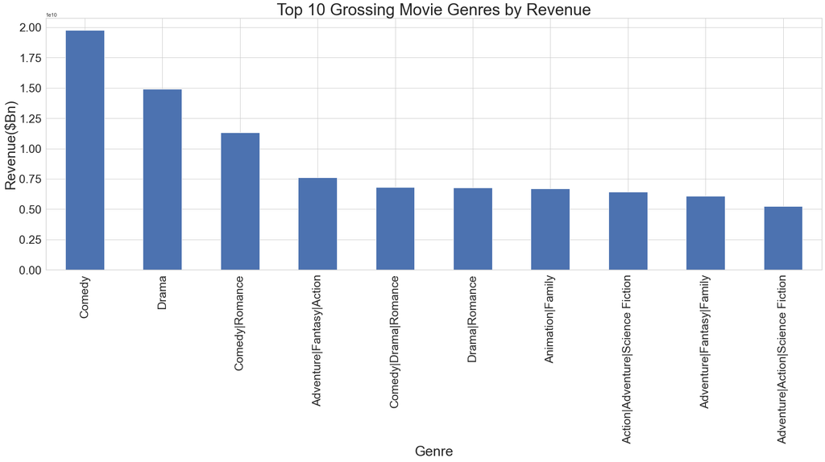

```python
#Visualize the top 10 Movie Genres that generated the most revenue using bar charts
genre_revenue.revenue.plot.bar(figsize=(30, 10), fontsize=25);

plt.title('Top 10 Grossing Movie Genres by Revenue',fontsize = 35)
plt.xlabel('Genre',fontsize = 30)
plt.ylabel('Revenue($Bn)',fontsize = 30);
```

```python
#Analyze the top 10 Movie Genres that generated the most profit
genre_profit = movies_df.groupby('genres').sum().sort_values(by='profit', ascending=False).head(10)
genre_profit
```

| genres | id | popularity | budget | revenue | runtime | vote_count | vote_average | release_year | profit |
| --- | --- | --- | --- | --- | --- | --- | --- | --- | --- |
| Comedy | 30032735 | 328.734720 | 6525485670 | 19779865016 | 49795 | 94911 | 3066.8 | 1050767 | 13254379346 |
| Drama | 43759577 | 321.569414 | 5600204656 | 14914250081 | 64532 | 92871 | 3619.5 | 1133304 | 9314045425 |
| Comedy\|Romance | 7570559 | 147.630594 | 3259566906 | 11331029666 | 22409 | 38553 | 1291.7 | 445850 | 8071462760 |
| Adventure\|Fantasy\|Action | 169808 | 56.751117 | 1776900000 | 7597483556 | 2042 | 41050 | 97.6 | 30027 | 5820583556 |
| Animation\|Family | 3543167 | 64.595691 | 1822500000 | 6697229242 | 3488 | 25553 | 367.6 | 112187 | 4874729242 |
| Action\|Adventure\|Science Fiction | 1467493 | 56.103093 | 1594500001 | 6420484308 | 2277 | 32972 | 121.3 | 42057 | 4825984307 |
| Adventure\|Fantasy\|Family | 78326 | 41.695908 | 1280000000 | 6079516484 | 1363 | 24133 | 69.8 | 20020 | 4799516484 |
| Comedy\|Drama\|Romance | 6025836 | 115.837666 | 2112234807 | 6827739420 | 19483 | 31164 | 1123.5 | 369907 | 4715504613 |
| Adventure\|Action\|Science Fiction | 186641 | 40.231896 | 893350000 | 5256276988 | 1458 | 28872 | 76.6 | 23927 | 4362926988 |
| Drama\|Romance | 9380234 | 149.490570 | 2605808040 | 6756200751 | 28145 | 39416 | 1563.4 | 496011 | 4150392711 |

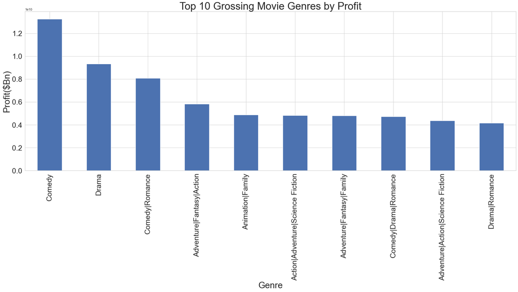

```python
#Visualize the top 10 Movie Genres that generated the most profit using bar charts
genre_profit.profit.plot.bar(figsize=(30, 10), fontsize=25);

plt.title('Top 10 Grossing Movie Genres by Profit',fontsize = 35)
plt.xlabel('Genre',fontsize = 30)
plt.ylabel('Profit($Bn)',fontsize = 30);
```

### Research Question 5 (Does higher budgets result in higher revenue?)

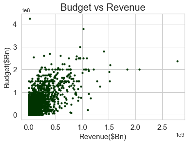

```python
#Visualize the impact of Budget on Revenue
movies_df.plot(y='budget', x='revenue', kind='scatter', color=(0,0.2,0),s=10, fontsize=15);

plt.title('Budget vs Revenue',fontsize = 20)
plt.ylabel('Budget($Bn)',fontsize = 15)
plt.xlabel('Revenue($Bn)',fontsize = 15);
```

### Research Question 6 (Does higher or increased revenue guarantee profits?)

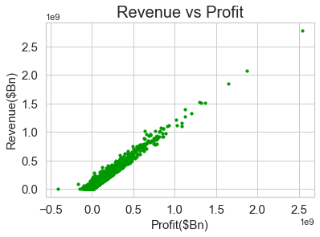

```python
#Make a scatter plot showing the relationship between revenue and profit generation
movies_df.plot(x='profit', y='revenue', kind='scatter', color=(0,0.6,0),s=10, fontsize=15);

plt.title('Revenue vs Profit',fontsize = 20)
plt.xlabel('Profit($Bn)',fontsize = 15)
plt.ylabel('Revenue($Bn)',fontsize = 15);
```

### Research Question 7 (Will higher budgets result in profit generation?)

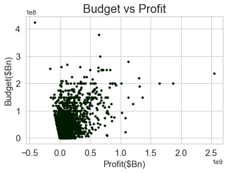

```python
#visualize the relationship between budget and profit using scatter plot
movies_df.plot(y='budget', x='profit', kind='scatter', color=(0,0.1,0),s=10, fontsize=15);

plt.title('Budget vs Profit',fontsize = 20)
plt.ylabel('Budget($Bn)',fontsize = 15)
plt.xlabel('Profit($Bn)',fontsize = 15);
```

#### This plot shows that increasing budget will not result in increased profit as the correlation is weak.

### Research Question 8 (Are movies with higher popularity ratings guaranteed to make profits?)

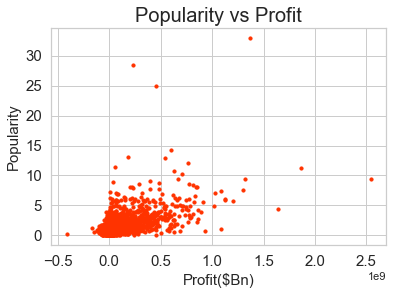

```python
#visualize the effect of popularity rating on profit generation using scatter plots
movies_df.plot(y='popularity', x='profit', kind='scatter', color=(1,0.2,0),s=10, fontsize=15);

plt.title('Popularity vs Profit',fontsize = 20)
plt.ylabel('Popularity',fontsize = 15)
plt.xlabel('Profit($Bn)',fontsize = 15);
```

#### This visual shows that there is a correlation between popularity and profit and even though there are outliers, it is possible that increased popularity can result in more profit.

### Research Question 9 (Does the popularity rating of a movie impact the revenue generation?)

[figure not shown]

```python
# analyze the effect of popularity rating on revenue generation using scatter plots
sns.set(style='whitegrid')
sns.set(font_scale=1.3)
sns.scatterplot(y='popularity', x='revenue', data= movies_df)

plt.title('Budget vs Profit',fontsize = 20)
plt.ylabel('Budget($Bn)',fontsize = 15)
plt.xlabel('Profit($Bn)',fontsize = 15);
```

#### This visual shows that there is a minor correlation between popularity and revenue with outliers evident. It is possible that increased popularity can result in more revenue.

### Research Question 10 (Do all movie productions generate revenue?)

```python
#Extract the count for movies that generated revenue and those that did not and also determine their percentage margins
revenue_movies = movies_df[movies_df['revenue'] > 0].shape[0]
no_revenue_movies = movies_df[movies_df['revenue'] <= 0].shape[0]
all_movies = movies_df.shape[0]

revenue_margins = pd.DataFrame({'revenue_ratings':['Revenue', 'No Revenue'],
                              'revenue_margin':[(revenue_movies/all_movies)*100, (no_revenue_movies/all_movies)*100]
                              })

revenue_margins.shape[1]
range(revenue_margins.shape[1])

revenue_margins.columns = range(revenue_margins.shape[1])

revenue_margins
```

|  | 0 | 1 |
| --- | --- | --- |
| 0 | Revenue | 52.342488 |
| 1 | No Revenue | 47.657512 |

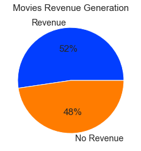

```python
#Use pie charts to visualize the percentage of movies that generated revenue to those that did not.
rev_data = revenue_margins[1]
rev_keys = revenue_margins[0]
r_color = sns.color_palette('bright')
plt.pie(rev_data, labels=rev_keys, colors=r_color, autopct='%.0f%%');
plt.title('Movies Revenue Generation',fontsize = 15);
```

#### Only 52% of the total movies generated revenues while the other 48% either made losses or generated not revenue at all.

### Research Question 11 (Does revenue generation from movie production guarantee profits?)

```python
#Extract the count for movies that generated profit, those that did not make profit and those that made losses and also determine their percentage margins
profit_movies = movies_df[movies_df['profit'] > 0].shape[0]
nonprofit_movies = movies_df[movies_df['profit'] == 0].shape[0]
loss_movies = movies_df[movies_df['profit'] < 0].shape[0]
all_movies = movies_df.shape[0]

profit_margins = pd.DataFrame({'profit_ratings':['Profitable', 'No Profit', 'Loss'],
                              'profit_margin':[(profit_movies/all_movies)*100, (nonprofit_movies/all_movies)*100, (loss_movies/all_movies)*100]
                              })

profit_margins.shape[1]
range(profit_margins.shape[1])

profit_margins.columns = range(profit_margins.shape[1])

profit_margins
```

|  | 0 | 1 |
| --- | --- | --- |
| 0 | Profitable | 40.976229 |
| 1 | No Profit | 35.564274 |
| 2 | Loss | 23.459497 |

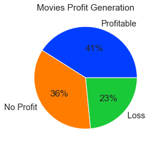

```python
#Use pie charts to visualize the percentage of movies that generated profit to those that did not and those that made losses.
data = profit_margins[1]
keys = profit_margins[0]
p_color = sns.color_palette('bright')
plt.pie(data, labels=keys, colors=p_color, autopct='%.0f%%');
plt.title('Movies Profit Generation',fontsize = 15);
```

## Limitations

- The dataset had a lot of missing and null values which resulted in the affected rows being deleted.
- The revenue and budget amounts did not have currency units to enable us ascertain the uniformity of the figures presented. I have adopted the USD(dollar) currency for this analysis.
- The dataset contains details of movies produced between 1960 and 2015 which might not be enough to make assumptions for the movie industry statistics of today.